# HW5

### ID:5207679

### Ex4.12

Let X<sub>2</sub>,…X<sub>60</sub> be a random sample of size 60 from a four-variate normal distribution having mean $\mu$ and covariance $\Sigma$. Specify each of the following completely.
(a)The distribution of $\bar{X}$
(b)The distribution of ($X_{1}-\mu$)‘$\Sigma^{-1}$($X_{1}-\mu$)
(c)The distribution of n($\bar{X}-\mu$)’$\Sigma^{-1}$($\bar{X}-\mu$)
(d)The approximate distribution of n($\bar{X}-\mu$)‘$S^{-1}$($\bar{X}-\mu$)
Solution:
(a)$\bar{X}$ ~ $N_{4}$($\mu$,$\frac{1}{60}$$\Sigma$)
(b)($X_{1}-\mu$)’$\Sigma^{-1}$($X_{1}-\mu$) ~ $\chi_{4}$($\alpha$)
(c)n($\bar{X}-\mu$)‘$\Sigma^{-1}$($\bar{X}-\mu$) ~ $\chi_{4}$($\alpha$)
(d)As the CLT, approximately n($\bar{X}-\mu$)’$S^{-1}$($\bar{X}-\mu$) ~d $\chi_{4}$($\alpha$)
Accurately, it follows (60-1)*4/(60-4)F<sub>4,60-4</sub>, which is 4.2F<sub>4,56</sub>

### Ex4.41

Consider the data on show removal in Ex3.20  
(a)Consider on any possible outliers in a scatter plot of the original variables  
(b)Determine the power transformation $\hat{\lambda_{1}}$ that makes the x<sub>1</sub> values approximately normal.Construct a Q-Q plot of the transformed observations.  
(c)Determine the power transformation $\hat{\lambda_{2}}$ that makes the x<sub>2</sub> values approximately normal.Construct a Q-Q plot of the transformed observations.  
(d)Determinr the power transformation for approximately bivariate normality using (4-40)  
Solution:  
(a) First load the data on snow removal

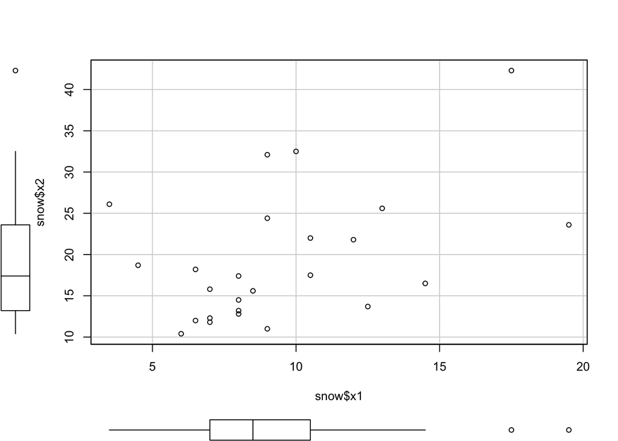

```r
snow <-read.table('http://users.stat.umn.edu/~guxxx192/courses/wichern_data/t3-2.dat')
colnames(snow)<-c('x1','x2')
library(car)
scatterplot(snow$x1,snow$x2,smoother= FALSE, reg.line=FALSE)
```

```r
library(MASS)
res<-boxcox(snow$x1~1, lambda=seq(-2,2,0.01) )
```

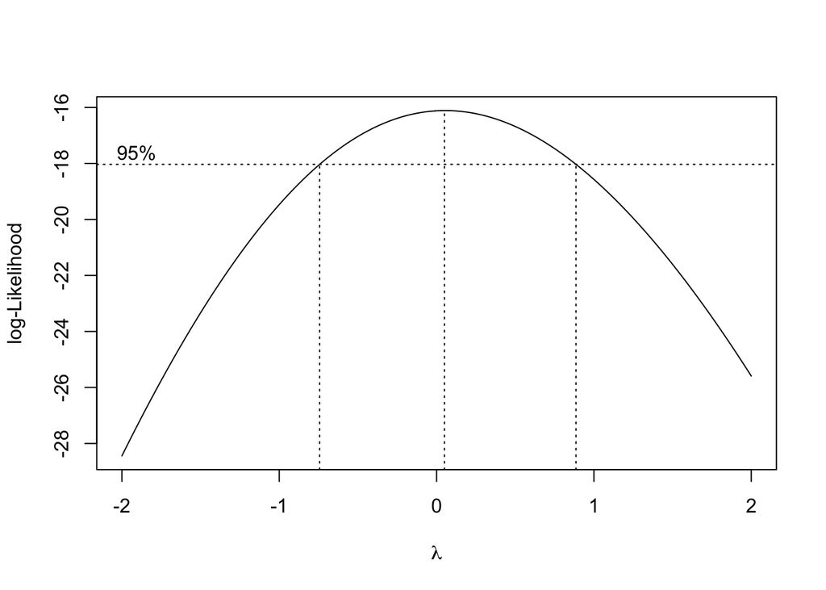

```r
print(lambda<-with(res,x[which.max(y)]))
```

```
## [1] 0.05
```

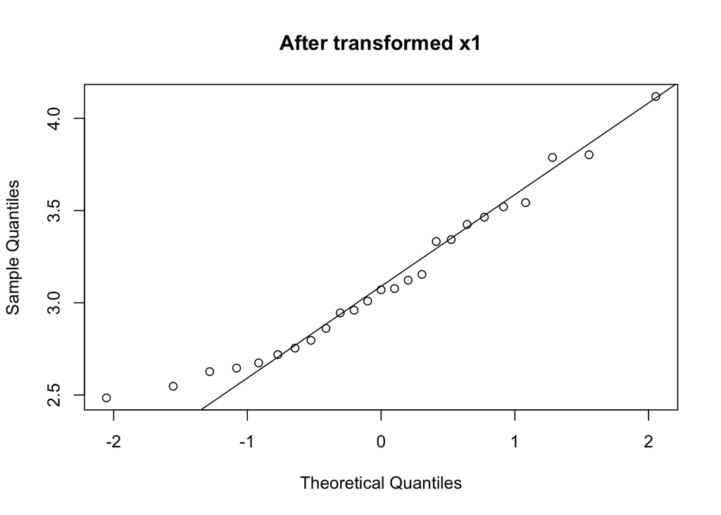

```r
x1_transformed<-(snow$x2^(0.05)-1)/(0.05)
qqnorm(x1_transformed,main="After transformed x1")
qqline(x1_transformed)
```

```r
res<-boxcox(snow$x2~1, lambda=seq(-2,2,0.01) )
```

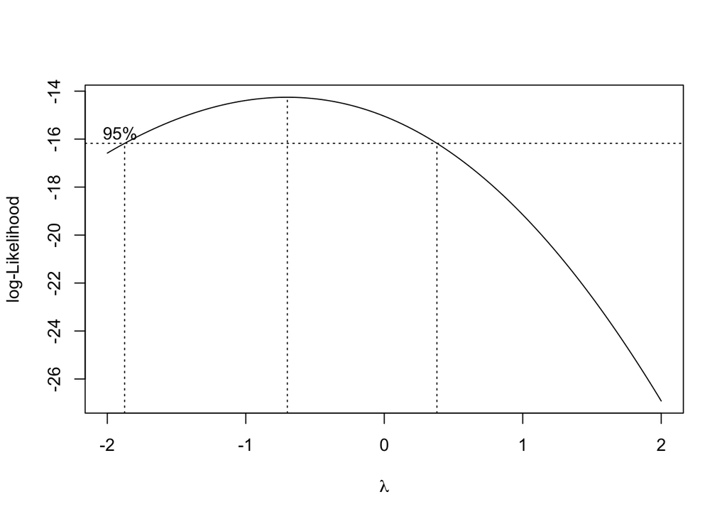

```r
print(lambda<-with(res,x[which.max(y)]))
```

```
## [1] -0.7
```

Choose -0.7 as the $\lambda_{2}$

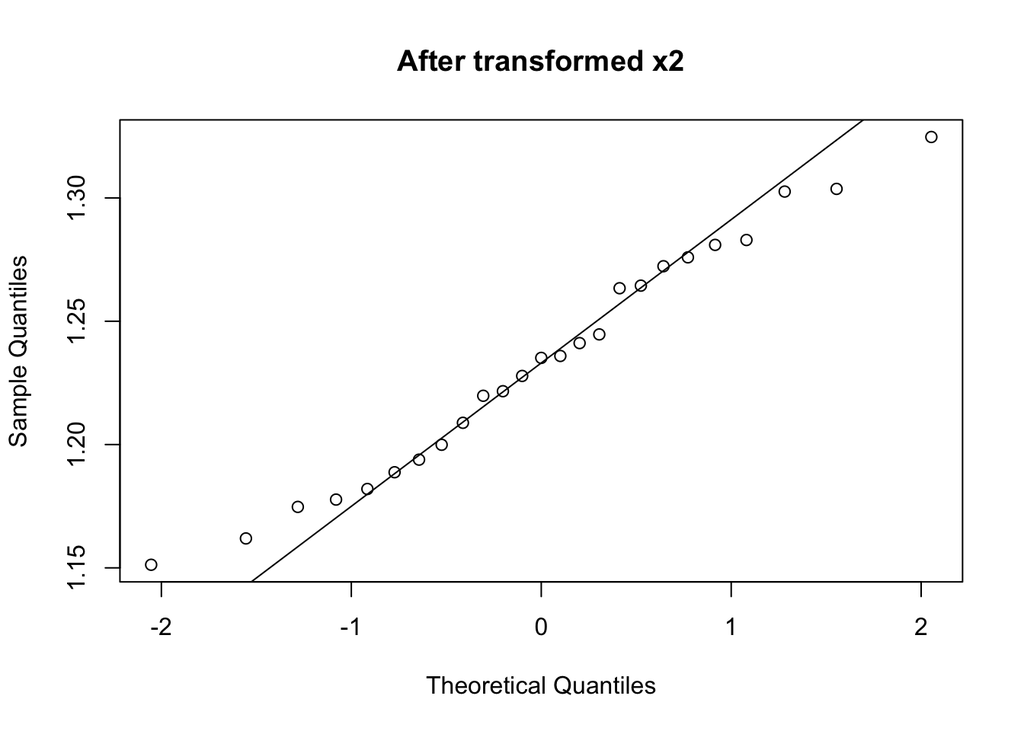

```r
x2_transformed<-(snow$x2^(-0.7)-1)/(-0.7)
qqnorm(x2_transformed,main="After transformed x2")
qqline(x2_transformed)
```

```r
res<-powerTransform(with(snow,cbind(x1,x2)) ~1)
summary(res)
```

```
## bcPower Transformations to Multinormality
##
##    Est.Power Std.Err. Wald Lower Bound Wald Upper Bound
## x1    0.2396   0.4058          -0.5558           1.0350
## x2   -0.6417   0.5688          -1.7565           0.4732
##
## Likelihood ratio tests about transformation parameters
##                               LRT df        pval
## LR test, lambda = (0 0)  1.711958  2 0.424867048
## LR test, lambda = (1 1) 12.454818  2 0.001974562
## LR test, lambda = (1 0)  4.647644  2 0.097898687
```

## Ex5.1

(a)Evaluating T<sup>2</sup>, for testing H<sub>0</sub>: $\mu$’=[7,11], using the data $X= \left( \begin{array}{ccc} 2 & 12\\ 8 & 9 \\ 6 & 9 \\ 8 & 10 \end{array} \right)$ (b)Specify the distribution of T<sup>2</sup> for the situation in (a)  
(c)Using (a) and (b), test H<sub>0</sub> at the %% =0.05 level. What conclusion do you reach?  
Solution:  
(a)

```r
x_51 <-matrix(c(2, 8, 6, 8,12,9, 9, 10),nrow=4, ncol=2)
xbar_51 <-colMeans( x_51)
mu_51<-c(7,11)
scov_51<-cov(x_51)
print(T2_51<- 4*t(xbar_51-mu_51) %*% solve(scov_51) %*% (xbar_51-mu_51))
```

```
##          [,1]
## [1,] 13.63636
```

2. T2_51 ~ (4-1)*2/(4-2) $F_{2,4-2}$($\alpha$), which is 3$F_{2,2}$($\alpha$)
3. Calculate the quantile for F distrbution

```r
3*qf(1-0.05, df1=2,df2=2)
```

```
## [1] 57
```

Since T2_51< 0.05th quantile, we can not reject the Null hypothesis.

### Ex 5.3

(a)Use expression (5-15) to calculate the T2 in Exercise 5.1  
(b)Use the data in Exercise 5.1 to evaluate $\Lambda$ in (5-13). Also, evaluate Wilks’ lambda.  
Solution:  
(a)

```r
n=4
Sigma.hat <- (n-1) * scov_51/n
Sigma0.hat <- Sigma.hat + (xbar_51 - mu_51) %*% t(xbar_51 -mu_51)
print(T2 <- (n - 1) * det(Sigma0.hat)/det(Sigma.hat) -(n - 1))
```

```
## [1] 13.63636
```

```r
print(LR_Statistic<-(det(Sigma.hat)/det(Sigma0.hat))^(n/2))
```

```
## [1] 0.03251814
```

```r
print(Wilk_lambda<-det(Sigma.hat)/det(Sigma0.hat))
```

```
## [1] 0.1803279
```

### Problem2

1. Since We have known population covariance is $\Sigma_{0}$, the dimension of $\theta_{0}$ space is 0.  
   The loglikelihood function is $\ell_{0}$=$\ell$($\mu_{0}$,$\Sigma_{0}$)= -$\frac{n}{2}$log|2$\pi\Sigma_{0}$|-$\frac{1}{2}$tr($\Sigma_{0}^{-1}\sum_{i=1}^{n}$($X_{i}-\mu_{0}$)‘($X_{i}-\mu_{0}$))+const  
   $\ell_{1}$=$\ell$($\bar{X}$,$\Sigma_{0}$)= -$\frac{n}{2}$log|2$\pi\Sigma_{0}$|-$\frac{1}{2}$tr($\Sigma_{0}^{-1}\sum_{i=1}^{n}$($X_{i}-\bar{X}$)’($X_{i}-\bar{X}$))+const  
   $\ell_{1}$-$\ell_{0}$=tr($\Sigma_{0}^{-1}\sum_{i=1}^{n}$($X_{i}-\mu_{0}$)‘($X_{i}-\mu_{0}$))-tr($\Sigma_{0}^{-1}\sum_{i=1}^{n}$($X_{i}-\bar{X}$)’($X_{i}-\bar{X}$)) =$\frac{n}{2}$tr($\Sigma_{0}^{-1}$($\bar{X}-\mu_{0}$)‘($\bar{X}-\mu_{0}$)) =n($\bar{X}-\mu_{0}$)’$\Sigma^{-1}$($\bar{X}-\mu_{0}$)  
   -2log$\lambda$=2($\ell_{1}$-$\ell_{0}$)=n($\bar{X}-\mu_{0}$)’$\Sigma_{-1}$($\bar{X}-\mu_{0}$) ~ $\chi_{p}^{2}$
2. Let Y<sub>i</sub>=a’X<sub>i</sub>  
   Since X<sub>i</sub> are iid observations from N<sub>p</sub>($\mu,\Sigma_{0}$), Y<sub>i</sub> are iid N(a’$\mu$, a’$\Sigma$a)  
   The null hyposhesis H<sub>0</sub>: $\mu=\mu_{0}$ is true ,if and only if all null hypothesis of the form H<sub>0</sub><sup>a</sup>: a’$\mu$=a’$\mu_{0}$ is true.  
   $\bar{Y}$ ~ N<sub>p</sub>(a’$\mu$,$\frac{1}{n}a'\Sigma_{0}a$)  
   $\frac{\bar{Y}-a'\mu_{0}}{\sqrt{\frac{1}{n}a'\Sigma_{0}a}}$ ~ N(a’($\mu-\mu_{0}$),1)  
   To find maximum range of previous foluma, take the square  
   $max_{a\not= 0}$($\frac{\bar{Y}-a'\mu_{0}}{\sqrt{\frac{1}{n}a'\Sigma_{0}a}}$)<sup>2</sup> =n* $max_{a\not= 0}$($\frac{(a'\bar{X}-\mu_{0})^{2}}{a'\Sigma_{0}a}$) =n($\bar{X}-\mu_{0}$)’$\Sigma^{-1}$($\bar{X}-\mu_{0}$) ~ $\chi_{p}^{2}$